# Chapter 4 - Stack Overflow questions

by Edneide Ramalho

16 Junho, 2021

# 1 The joinning verbs

- Inner join
- Left join
- Right join
- Full join
- Semi join
- Anti join

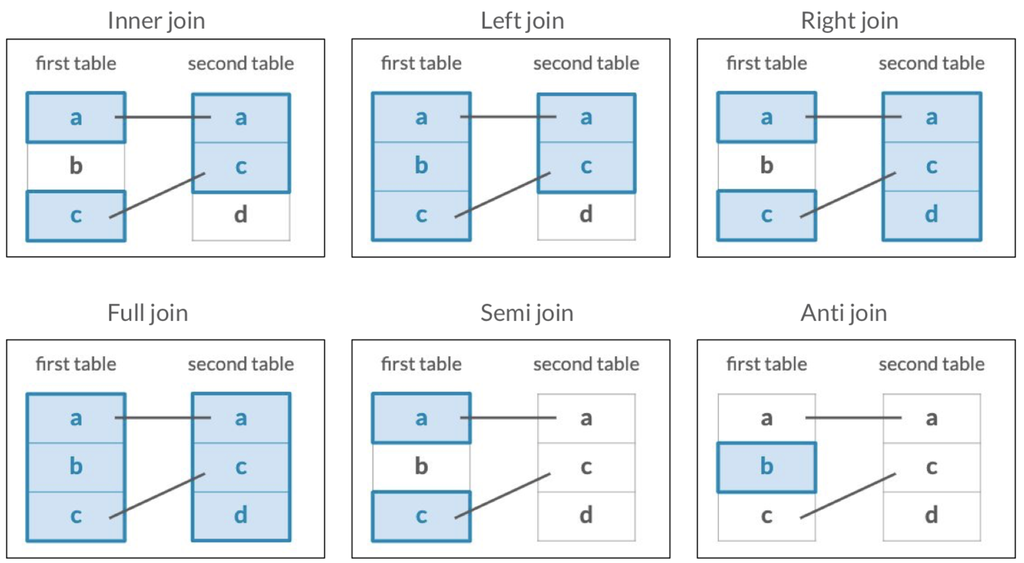

## 1.1 The questions table

```r
library(tidyverse)
head(questions)
```

```
## # A tibble: 6 x 3
##         id creation_date score
##      <dbl> <date>        <dbl>
## 1 22557677 2014-03-21        1
## 2 22557707 2014-03-21        2
## 3 22558084 2014-03-21        2
## 4 22558395 2014-03-21        2
## 5 22558613 2014-03-21        0
## 6 22558677 2014-03-21        2
```

```r
head(question_tags)
```

```
## # A tibble: 6 x 2
##   question_id tag_id
##         <dbl>  <dbl>
## 1    22557677     18
## 2    22557677    139
## 3    22557677  16088
## 4    22557677   1672
## 5    22558084   6419
## 6    22558084  92764
```

```r
head(tags)
```

```
## # A tibble: 6 x 2
##       id tag_name
##    <dbl> <chr>
## 1 124399 laravel-dusk
## 2 124402 spring-cloud-vault-config
## 3 124404 spring-vault
## 4 124405 apache-bahir
## 5 124407 astc
## 6 124408 simulacrum
```

## 1.2 Joining data

```r
questions_with_tags <- questions %>%
  inner_join(question_tags, by = c("id" = "question_id")) %>%
  inner_join(tags, by = c("tag_id" = "id"))
questions_with_tags
```

```
## # A tibble: 497,153 x 5
##          id creation_date score tag_id tag_name
##       <dbl> <date>        <dbl>  <dbl> <chr>
##  1 22557677 2014-03-21        1     18 regex
##  2 22557677 2014-03-21        1    139 string
##  3 22557677 2014-03-21        1  16088 time-complexity
##  4 22557677 2014-03-21        1   1672 backreference
##  5 22558084 2014-03-21        2   6419 time-series
##  6 22558084 2014-03-21        2  92764 panel-data
##  7 22558395 2014-03-21        2   5569 function
##  8 22558395 2014-03-21        2    134 sorting
##  9 22558395 2014-03-21        2   9412 vectorization
## 10 22558395 2014-03-21        2  18621 operator-precedence
## # … with 497,143 more rows
```

## 1.3 Most common tags

```r
questions_with_tags %>%
  count(tag_name, sort = TRUE)
```

```
## # A tibble: 7,840 x 2
##    tag_name       n
##    <chr>      <int>
##  1 ggplot2    28228
##  2 dataframe  18874
##  3 shiny      14219
##  4 dplyr      14039
##  5 plot       11315
##  6 data.table  8809
##  7 matrix      6205
##  8 loops       5149
##  9 regex       4912
## 10 function    4892
## # … with 7,830 more rows
```

## 1.4 Exercises

### 1.4.1 **Left-joining questions and tags**

Three of the Stack Overflow survey datasets are `questions`, `question_tags`, and `tags`:

- `questions`: an ID and the score, or how many times the question has been upvoted; the data only includes R-based questions
- `question_tags`: a tag ID for each question and the question’s id
- `tags`: a tag id and the tag’s name, which can be used to identify the subject of each question, such as ggplot2 or dplyr

In this exercise, we’ll be stitching together these datasets and replacing NAs in important fields.

Note that we’ll be using `left_join`s in this exercise to ensure we keep all questions, even those without a corresponding tag. However, since we know the `questions` data is all R data, we’ll want to manually tag these as R questions with `replace_na`.

- Join together `questions` and `question_tags` using the `id` and `question_id` columns, respectively.

```r
# Join the questions and question_tags tables
questions_with_tags <- questions %>%
    left_join(question_tags, by = c("id" = "question_id"))
```

- Use another join to add in the `tags` table.

```r
# Join in the tags table
questions_with_tags <- questions %>%
    left_join(question_tags, by = c("id" = "question_id")) %>%
    left_join(tags, by = c("tag_id" = "id"))
```

- Use `replace_na` to change the `NA`s in the `tag_name` column to `"only-r"`.

```r
# Replace the NAs in the tag_name column
questions_with_tags <- questions %>%
  left_join(question_tags, by = c("id" = "question_id")) %>%
  left_join(tags, by = c("tag_id" = "id")) %>%
  replace_na(list(tag_name = "only-r"))
```

### 1.4.2 **Comparing scores across tags**

The complete dataset you created in the last exercise is available to you as `questions_with_tags`. Let’s do a quick bit of analysis on it! You’ll use familiar dplyr verbs like `group_by`, `summarize`, `arrange`, and `n` to find out the average score of the most asked questions.

- Aggregate by the `tag_name`.
- Summarize to get the total number of questions, `num_questions`, as well as the mean score for each question, `score`.
- Arrange `num_questions` in descending order to sort the answers by the most asked questions.

```r
questions_with_tags %>%
    # Group by tag_name
    group_by(tag_name) %>%
    # Get mean score and num_questions
    summarize(score = mean(score),
              num_questions = n()) %>%
    # Sort num_questions in descending order
    arrange(desc(num_questions))
```

```
## # A tibble: 7,841 x 3
##    tag_name   score num_questions
##    <chr>      <dbl>         <int>
##  1 only-r     1.26          48541
##  2 ggplot2    2.61          28228
##  3 dataframe  2.31          18874
##  4 shiny      1.45          14219
##  5 dplyr      1.95          14039
##  6 plot       2.24          11315
##  7 data.table 2.97           8809
##  8 matrix     1.66           6205
##  9 loops      0.743          5149
## 10 regex      2              4912
## # … with 7,831 more rows
```

### 1.4.3 **What tags never appear on R questions?**

The `tags` table includes all Stack Overflow tags, but some have nothing to do with `R`. How could you filter for just the tags that never appear on an R question? The `tags` and `question_tags` tables have been preloaded for you.

- Use a join to determine which tags never appear on an R question.

```r
# Using a join, filter for tags that are never on an R question
tags %>%
  anti_join(question_tags,
            by = c("id" = "tag_id"))
```

```
## # A tibble: 40,459 x 2
##        id tag_name
##     <dbl> <chr>
##  1 124399 laravel-dusk
##  2 124402 spring-cloud-vault-config
##  3 124404 spring-vault
##  4 124405 apache-bahir
##  5 124407 astc
##  6 124408 simulacrum
##  7 124410 angulartics2
##  8 124411 django-rest-viewsets
##  9 124414 react-native-lightbox
## 10 124417 java-module
## # … with 40,449 more rows
```

# 2 Joining questions and answers

## 2.1 The answers table

```r
head(answers)
```

```
## # A tibble: 6 x 4
##         id creation_date question_id score
##      <dbl> <date>              <dbl> <dbl>
## 1 39143713 2016-08-25       39143518     3
## 2 39143869 2016-08-25       39143518     1
## 3 39143935 2016-08-25       39142481     0
## 4 39144014 2016-08-25       39024390     0
## 5 39144252 2016-08-25       39096741     6
## 6 39144375 2016-08-25       39143885     5
```

```r
questions %>%
  inner_join(answers, by = c("id" = "question_id"))
```

```
## # A tibble: 380,643 x 6
##          id creation_date.x score.x     id.y creation_date.y score.y
##       <dbl> <date>            <dbl>    <dbl> <date>            <dbl>
##  1 22557677 2014-03-21            1 22560670 2014-03-21            2
##  2 22557707 2014-03-21            2 22558516 2014-03-21            1
##  3 22557707 2014-03-21            2 22558726 2014-03-21            4
##  4 22558084 2014-03-21            2 22558085 2014-03-21            0
##  5 22558084 2014-03-21            2 22606545 2014-03-24            1
##  6 22558084 2014-03-21            2 22610396 2014-03-24            5
##  7 22558084 2014-03-21            2 34374729 2015-12-19            0
##  8 22558395 2014-03-21            2 22559327 2014-03-21            1
##  9 22558395 2014-03-21            2 22560102 2014-03-21            2
## 10 22558395 2014-03-21            2 22560288 2014-03-21            2
## # … with 380,633 more rows
```

## 2.2 Exercises

### 2.2.1 **Finding gaps between questions and answers**

Now we’ll join together `questions` with `answers` so we can measure the time between questions and answers.

Make sure to explore the tables and columns in the console before starting the exercise. Can you tell how are questions identified in the `questions` table? How can you identify which answer corresponds to which question using the `answers` table?

- Use an inner join to combine the `questions` and `answers` tables using the suffixes `"_question"` and `"_answer"`, respectively.
- Subtract `creation_date_question` from `creation_date_answer` within the `as.integer()` function to create the `gap` column.

*If your exercise is timing out, you are likely using the wrong columns for joining, causing the result to be too big! Check the join fields carefully!*

- In the `questions` table, the questions are identified by the `id` column, and by the `question_id` in the `answers` table.

```r
questions %>%
    # Inner join questions and answers with proper suffixes
    inner_join(answers, by = c("id" = "question_id"), suffix = c("_question", "_answer")) %>%
    # Subtract creation_date_question from creation_date_answer to create gap
    mutate(gap = as.integer(creation_date_answer - creation_date_question))
```

```
## # A tibble: 380,643 x 7
##          id creation_date_question score_question id_answer creation_date_answer
##       <dbl> <date>                          <dbl>     <dbl> <date>
##  1 22557677 2014-03-21                          1  22560670 2014-03-21
##  2 22557707 2014-03-21                          2  22558516 2014-03-21
##  3 22557707 2014-03-21                          2  22558726 2014-03-21
##  4 22558084 2014-03-21                          2  22558085 2014-03-21
##  5 22558084 2014-03-21                          2  22606545 2014-03-24
##  6 22558084 2014-03-21                          2  22610396 2014-03-24
##  7 22558084 2014-03-21                          2  34374729 2015-12-19
##  8 22558395 2014-03-21                          2  22559327 2014-03-21
##  9 22558395 2014-03-21                          2  22560102 2014-03-21
## 10 22558395 2014-03-21                          2  22560288 2014-03-21
## # … with 380,633 more rows, and 2 more variables: score_answer <dbl>, gap <int>
```

### 2.2.2 **Joining question and answer counts**

We can also determine how many questions actually yield answers. If we count the number of answers for each question, we can then join the answers counts with the `questions` table.

- Count and sort the `question_id` column in the `answers` table to create the `answer_counts` table.
- Join the `questions` table with the `answer_counts` table.
- Replace the NA values in the `n` column with 0s.

```r
# Count and sort the question id column in the answers table
answer_counts <- answers %>%
    group_by(question_id) %>%
    summarize(n = n())



# Combine the answer_counts and questions tables
questions %>%
    left_join(answer_counts, by = c("id" = "question_id")) %>%
    # Replace the NAs in the n column
    replace_na(list(n = 0))
```

```
## # A tibble: 294,735 x 4
##          id creation_date score     n
##       <dbl> <date>        <dbl> <dbl>
##  1 22557677 2014-03-21        1     1
##  2 22557707 2014-03-21        2     2
##  3 22558084 2014-03-21        2     4
##  4 22558395 2014-03-21        2     3
##  5 22558613 2014-03-21        0     1
##  6 22558677 2014-03-21        2     2
##  7 22558887 2014-03-21        8     1
##  8 22559180 2014-03-21        1     1
##  9 22559312 2014-03-21        0     1
## 10 22559322 2014-03-21        2     5
## # … with 294,725 more rows
```

### 2.2.3 Joining questions, answers, and tags

Let’s build on the last exercise by adding the tags table to our previous joins. This will allow us to do a better job of identifying which R topics get the most traction on Stack Overflow. The tables you created in the last exercise have been preloaded for you as answer_counts and question_answer_counts.

```r
answer_counts <- answers %>% count(question_id, sort = TRUE)

question_answer_counts <- questions %>% left_join(answer_counts, by = c("id" = "question_id")) %>% replace_na(list(n = 0))
```

Combine the question_tags table with question_answer_counts using an inner_join. Now, use another inner_join to add the tags table.

```r
question_answer_counts %>%
    # Join the question_tags tables
    inner_join(question_tags, by = c("id" = "question_id")) %>%
    # Join the tags table
  inner_join(tags, by = c("tag_id" = "id"))
```

```
## # A tibble: 497,153 x 6
##          id creation_date score     n tag_id tag_name
##       <dbl> <date>        <dbl> <dbl>  <dbl> <chr>
##  1 22557677 2014-03-21        1     1     18 regex
##  2 22557677 2014-03-21        1     1    139 string
##  3 22557677 2014-03-21        1     1  16088 time-complexity
##  4 22557677 2014-03-21        1     1   1672 backreference
##  5 22558084 2014-03-21        2     4   6419 time-series
##  6 22558084 2014-03-21        2     4  92764 panel-data
##  7 22558395 2014-03-21        2     3   5569 function
##  8 22558395 2014-03-21        2     3    134 sorting
##  9 22558395 2014-03-21        2     3   9412 vectorization
## 10 22558395 2014-03-21        2     3  18621 operator-precedence
## # … with 497,143 more rows
```

### 2.2.4 Average answers by question

The table you created in the last exercise has been preloaded for you as `tagged_answers`. You can use this table to determine, on average, how many answers each questions gets.

```r
tagged_answers <- question_answer_counts %>%
    inner_join(question_tags, by = c("id" = "question_id")) %>%
    inner_join(tags, by = c("tag_id" = "id"))
```

Some of the important variables from this table include: `n`, the number of answers for each question, and `tag_name`, the name of each tag associated with each question.

Let’s use some of our favorite dplyr verbs to find out how many answers each question gets on average.

- Aggregate the `tagged_answers` table by `tag_name`.
- Summarize `tagged_answers` to get the count of `questions` and the `average_answers`.
- Sort the resulting `questions` column in descending order.

```r
tagged_answers %>%
    # Aggregate by tag_name
  group_by(tag_name) %>%
    # Summarize questions and average_answers
    summarize(questions = n(),
              average_answers = mean(n)) %>%
    # Sort the questions in descending order
  arrange(desc(questions))
```

```
## # A tibble: 7,840 x 3
##    tag_name   questions average_answers
##    <chr>          <int>           <dbl>
##  1 ggplot2        28228           1.15
##  2 dataframe      18874           1.67
##  3 shiny          14219           0.921
##  4 dplyr          14039           1.55
##  5 plot           11315           1.23
##  6 data.table      8809           1.47
##  7 matrix          6205           1.45
##  8 loops           5149           1.39
##  9 regex           4912           1.91
## 10 function        4892           1.30
## # … with 7,830 more rows
```

# 3 **The bind_rows verb**

- Sometimes, we want to stuck a table at the top of another.

```r
questions %>%
  bind_rows(answers)
```

```
## # A tibble: 675,378 x 4
##          id creation_date score question_id
##       <dbl> <date>        <dbl>       <dbl>
##  1 22557677 2014-03-21        1          NA
##  2 22557707 2014-03-21        2          NA
##  3 22558084 2014-03-21        2          NA
##  4 22558395 2014-03-21        2          NA
##  5 22558613 2014-03-21        0          NA
##  6 22558677 2014-03-21        2          NA
##  7 22558887 2014-03-21        8          NA
##  8 22559180 2014-03-21        1          NA
##  9 22559312 2014-03-21        0          NA
## 10 22559322 2014-03-21        2          NA
## # … with 675,368 more rows
```

It is important to track the tables adding one more column to identify if it is from the question or the answer table.

## 3.1 Using bind rows

```r
questions_type <- questions %>%
  mutate(type = "question")
```

```r
answers_type <- answers %>%
  mutate(type = "answer")
```

```r
questions_type
```

```
## # A tibble: 294,735 x 4
##          id creation_date score type
##       <dbl> <date>        <dbl> <chr>
##  1 22557677 2014-03-21        1 question
##  2 22557707 2014-03-21        2 question
##  3 22558084 2014-03-21        2 question
##  4 22558395 2014-03-21        2 question
##  5 22558613 2014-03-21        0 question
##  6 22558677 2014-03-21        2 question
##  7 22558887 2014-03-21        8 question
##  8 22559180 2014-03-21        1 question
##  9 22559312 2014-03-21        0 question
## 10 22559322 2014-03-21        2 question
## # … with 294,725 more rows
```

```r
answers_type
```

```
## # A tibble: 380,643 x 5
##          id creation_date question_id score type
##       <dbl> <date>              <dbl> <dbl> <chr>
##  1 39143713 2016-08-25       39143518     3 answer
##  2 39143869 2016-08-25       39143518     1 answer
##  3 39143935 2016-08-25       39142481     0 answer
##  4 39144014 2016-08-25       39024390     0 answer
##  5 39144252 2016-08-25       39096741     6 answer
##  6 39144375 2016-08-25       39143885     5 answer
##  7 39144430 2016-08-25       39144077     0 answer
##  8 39144625 2016-08-25       39142728     1 answer
##  9 39144794 2016-08-25       39043648     0 answer
## 10 39145033 2016-08-25       39133170     1 answer
## # … with 380,633 more rows
```

```r
posts <- bind_rows(questions_type, answers_type)
posts
```

```
## # A tibble: 675,378 x 5
##          id creation_date score type     question_id
##       <dbl> <date>        <dbl> <chr>          <dbl>
##  1 22557677 2014-03-21        1 question          NA
##  2 22557707 2014-03-21        2 question          NA
##  3 22558084 2014-03-21        2 question          NA
##  4 22558395 2014-03-21        2 question          NA
##  5 22558613 2014-03-21        0 question          NA
##  6 22558677 2014-03-21        2 question          NA
##  7 22558887 2014-03-21        8 question          NA
##  8 22559180 2014-03-21        1 question          NA
##  9 22559312 2014-03-21        0 question          NA
## 10 22559322 2014-03-21        2 question          NA
## # … with 675,368 more rows
```

## 3.2 Aggregating

```r
posts %>%
  group_by(type) %>%
  summarize(average_score = mean(score))
```

```
## # A tibble: 2 x 2
##   type     average_score
##   <chr>            <dbl>
## 1 answer            2.88
## 2 question          1.90
```

## 3.3 Creating date variable

```r
library(lubridate)
posts %>%
  mutate(year = year(creation_date))
```

```
## # A tibble: 675,378 x 6
##          id creation_date score type     question_id  year
##       <dbl> <date>        <dbl> <chr>          <dbl> <dbl>
##  1 22557677 2014-03-21        1 question          NA  2014
##  2 22557707 2014-03-21        2 question          NA  2014
##  3 22558084 2014-03-21        2 question          NA  2014
##  4 22558395 2014-03-21        2 question          NA  2014
##  5 22558613 2014-03-21        0 question          NA  2014
##  6 22558677 2014-03-21        2 question          NA  2014
##  7 22558887 2014-03-21        8 question          NA  2014
##  8 22559180 2014-03-21        1 question          NA  2014
##  9 22559312 2014-03-21        0 question          NA  2014
## 10 22559322 2014-03-21        2 question          NA  2014
## # … with 675,368 more rows
```

## 3.4 Counting date variable

```r
question_answer_years <- posts %>%
  mutate(year = year(creation_date)) %>%
  count(year, type)
question_answer_years
```

```
## # A tibble: 24 x 3
##     year type         n
##    <dbl> <chr>    <int>
##  1  2008 answer      27
##  2  2008 question     8
##  3  2009 answer    1361
##  4  2009 question   524
##  5  2010 answer    4847
##  6  2010 question  2264
##  7  2011 answer   11079
##  8  2011 question  5837
##  9  2012 answer   18967
## 10  2012 question 12210
## # … with 14 more rows
```

## 3.5 Plotting date variable

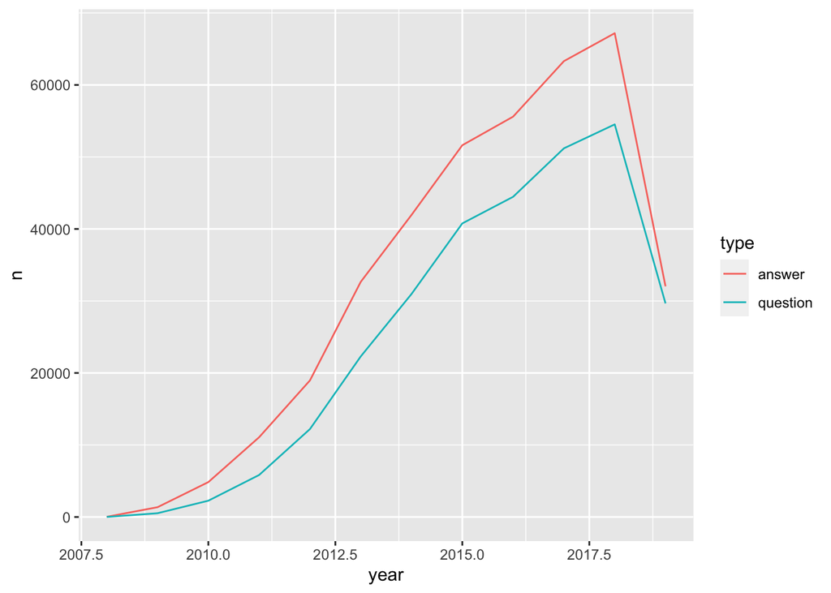

```r
question_answer_years %>%
  ggplot(aes(year, n, color = type)) +
  geom_line()
```

## 3.6 Exercises

### 3.6.1 **Joining questions and answers with tags**

To learn more about the `questions` and `answers` table, you’ll want to use the `question_tags` table to understand the tags associated with each question that was asked, and each answer that was provided. You’ll be able to combine these tables using two inner joins on both the `questions` table and the `answers` table.

- Use two inner joins to combine the `question_tags` and `tags` tables with the `questions` table.
- Now, use two inner joins to combine the `question_tags` and `tags` tables with the `answers` table.

```r
# Inner join the question_tags and tags tables with the questions table
questions %>%
  inner_join(question_tags, by = c("id" = "question_id")) %>%
  inner_join(tags, by = c("tag_id" = "id"))
```

```
## # A tibble: 497,153 x 5
##          id creation_date score tag_id tag_name
##       <dbl> <date>        <dbl>  <dbl> <chr>
##  1 22557677 2014-03-21        1     18 regex
##  2 22557677 2014-03-21        1    139 string
##  3 22557677 2014-03-21        1  16088 time-complexity
##  4 22557677 2014-03-21        1   1672 backreference
##  5 22558084 2014-03-21        2   6419 time-series
##  6 22558084 2014-03-21        2  92764 panel-data
##  7 22558395 2014-03-21        2   5569 function
##  8 22558395 2014-03-21        2    134 sorting
##  9 22558395 2014-03-21        2   9412 vectorization
## 10 22558395 2014-03-21        2  18621 operator-precedence
## # … with 497,143 more rows
```

```r
# Inner join the question_tags and tags tables with the answers table
answers %>%
  inner_join(question_tags, by = "question_id") %>%
  inner_join(tags, by = c("tag_id" = "id"))
```

```
## # A tibble: 625,845 x 6
##          id creation_date question_id score tag_id tag_name
##       <dbl> <date>              <dbl> <dbl>  <dbl> <chr>
##  1 39143935 2016-08-25       39142481     0   4240 average
##  2 39143935 2016-08-25       39142481     0   5571 summary
##  3 39144014 2016-08-25       39024390     0  85748 shiny
##  4 39144014 2016-08-25       39024390     0  83308 r-markdown
##  5 39144014 2016-08-25       39024390     0 116736 htmlwidgets
##  6 39144252 2016-08-25       39096741     6  67746 rstudio
##  7 39144375 2016-08-25       39143885     5 105113 data.table
##  8 39144430 2016-08-25       39144077     0    276 variables
##  9 39144625 2016-08-25       39142728     1  46457 dataframe
## 10 39144625 2016-08-25       39142728     1   9047 subset
## # … with 625,835 more rows
```

### 3.6.2 **Binding and counting posts with tags**

The tables you created in the previous exercise have been preloaded as `questions_with_tags` and `answers_with_tags`. First, you’ll want to combine these tables into a single table called `posts_with_tags`. Once the information is consolidated into a single table, you can add more information by creating a date variable using the `lubridate` package, which has been preloaded for you.

```r
questions_with_tags <- questions %>%
  inner_join(question_tags, by = c("id" = "question_id")) %>%
  inner_join(tags, by = c("tag_id" = "id"))
```

```r
answers_with_tags <- answers %>%
  inner_join(question_tags, by = "question_id") %>%
  inner_join(tags, by = c("tag_id" = "id"))
```

- Combine the `questions_with_tags` and `answers_with_tags` tables into `posts_with_tags`.
- Add a `year` column to the `posts_with_tags` table, then aggregate to count posts by `type`, `year`, and `tag_name`.

```r
# Combine the two tables into posts_with_tags
posts_with_tags <- bind_rows(questions_with_tags %>% mutate(type = "question"),
                              answers_with_tags %>% mutate(type = "answer"))


# Add a year column, then aggregate by type, year, and tag_name
posts_with_tags %>%
    mutate(year = year(creation_date)) %>%
    count(type, year, tag_name)
```

```
## # A tibble: 58,299 x 4
##    type    year tag_name                      n
##    <chr>  <dbl> <chr>                     <int>
##  1 answer  2008 bayesian                      1
##  2 answer  2008 dataframe                     3
##  3 answer  2008 dirichlet                     1
##  4 answer  2008 eof                           1
##  5 answer  2008 file                          1
##  6 answer  2008 file-io                       1
##  7 answer  2008 function                      7
##  8 answer  2008 global-variables              7
##  9 answer  2008 math                          2
## 10 answer  2008 mathematical-optimization     1
## # … with 58,289 more rows
```

### 3.6.3 **Visualizing questions and answers in tags**

In the last exercise, you modified the `posts_with_tags` table to add a `year` column, and aggregated by `type`, `year`, and `tag_name`. The modified table has been preloaded for you as `by_type_year_tag`, and has one observation for each type (question/answer), year, and tag. Let’s create a plot to examine the information that the table contains about questions and answers for the `dplyr` and `ggplot2` tags. The `ggplot2` package has been preloaded for you.

```r
by_type_year_tag <- posts_with_tags %>%
  mutate(year = year(creation_date)) %>%
  count(type, year, tag_name)
```

- Filter the `by_type_year_tag` table for the dplyr and ggplot2 tags.
- Create a line plot with that filtered table that plots the frequency (`n`) over time, colored by question/answer and faceted by tag.

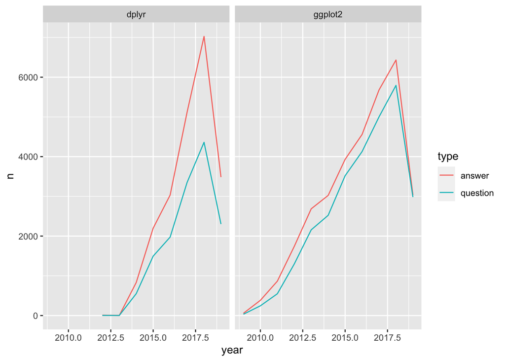

```r
# Filter for the dplyr and ggplot2 tag names
by_type_year_tag_filtered <- by_type_year_tag %>%
  filter(tag_name %in% c("dplyr", "ggplot2"))

# Create a line plot faceted by the tag name
ggplot(by_type_year_tag_filtered, aes(x = year, y = n, color = type)) +
  geom_line() +
  facet_wrap(~ tag_name)
```